# White Wine Quality Study

Ryan Winn

November 3, 2021

This report will explore a dataset that contains quality data for approximately 5,000 different white wines.

The first thing we will do, is set the environment for study by setting the working directory, bringing our file in for exploration, and testing the environment by checking for column headers.

```
## [1] "A:/Dev/R/White Wine Study"
```

```
##  [1] "X"                    "fixed.acidity"        "volatile.acidity"
##  [4] "citric.acid"          "residual.sugar"       "chlorides"
##  [7] "free.sulfur.dioxide"  "total.sulfur.dioxide" "density"
## [10] "pH"                   "sulphates"            "alcohol"
## [13] "quality"
```

Once we see that our data has loaded properly, we can load the packages needed for the study. The only library I loaded into this study is the ggplot2 library to build some of the plots.

# Univariate Plots

We first explore the shape of our quality values by examining the distribution curve shape.

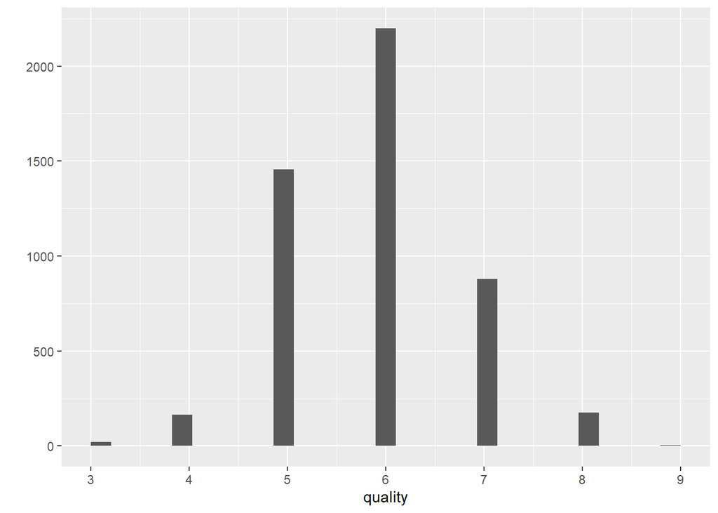

We can see the data is distributed normally, so we should look to use the middle values of the data, qualities 5-7, to show the trends in the data.

We chart this data in a summary table to take a cursory glance at our dataset.

```
##        X        fixed.acidity    volatile.acidity  citric.acid
##  Min.   :   1   Min.   : 3.800   Min.   :0.0800   Min.   :0.0000
##  1st Qu.:1225   1st Qu.: 6.300   1st Qu.:0.2100   1st Qu.:0.2700
##  Median :2450   Median : 6.800   Median :0.2600   Median :0.3200
##  Mean   :2450   Mean   : 6.855   Mean   :0.2782   Mean   :0.3342
##  3rd Qu.:3674   3rd Qu.: 7.300   3rd Qu.:0.3200   3rd Qu.:0.3900
##  Max.   :4898   Max.   :14.200   Max.   :1.1000   Max.   :1.6600
##  residual.sugar     chlorides       free.sulfur.dioxide total.sulfur.dioxide
##  Min.   : 0.600   Min.   :0.00900   Min.   :  2.00      Min.   :  9.0
##  1st Qu.: 1.700   1st Qu.:0.03600   1st Qu.: 23.00      1st Qu.:108.0
##  Median : 5.200   Median :0.04300   Median : 34.00      Median :134.0
##  Mean   : 6.391   Mean   :0.04577   Mean   : 35.31      Mean   :138.4
##  3rd Qu.: 9.900   3rd Qu.:0.05000   3rd Qu.: 46.00      3rd Qu.:167.0
##  Max.   :65.800   Max.   :0.34600   Max.   :289.00      Max.   :440.0
##     density             pH          sulphates         alcohol
##  Min.   :0.9871   Min.   :2.720   Min.   :0.2200   Min.   : 8.00
##  1st Qu.:0.9917   1st Qu.:3.090   1st Qu.:0.4100   1st Qu.: 9.50
##  Median :0.9937   Median :3.180   Median :0.4700   Median :10.40
##  Mean   :0.9940   Mean   :3.188   Mean   :0.4898   Mean   :10.51
##  3rd Qu.:0.9961   3rd Qu.:3.280   3rd Qu.:0.5500   3rd Qu.:11.40
##  Max.   :1.0390   Max.   :3.820   Max.   :1.0800   Max.   :14.20
##     quality
##  Min.   :3.000
##  1st Qu.:5.000
##  Median :6.000
##  Mean   :5.878
##  3rd Qu.:6.000
##  Max.   :9.000
```

The first thought that jumps out to me is that almost every column has a rediculously high max number compared to the 3rd quartile value. As the analysis progresses, I will need to cut some values off the graphs to show any actual trends in the data.

Now we will plot each value field on a histogram to try and form an initial hypothesis as to what we believe is having the largest effect on the quality.

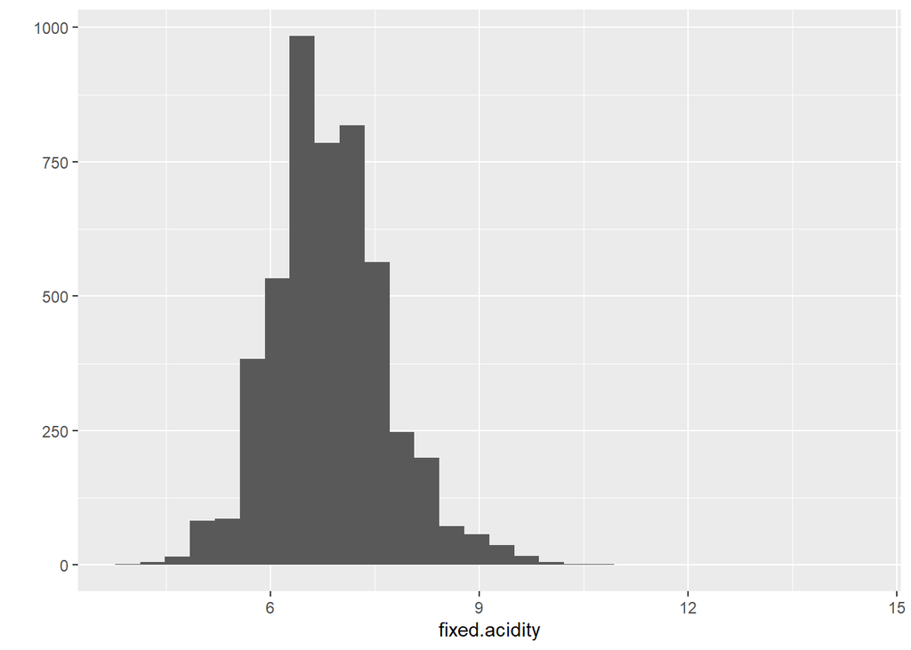

Fixed Acidity seems to be concentrated around the 6-9 unit range.

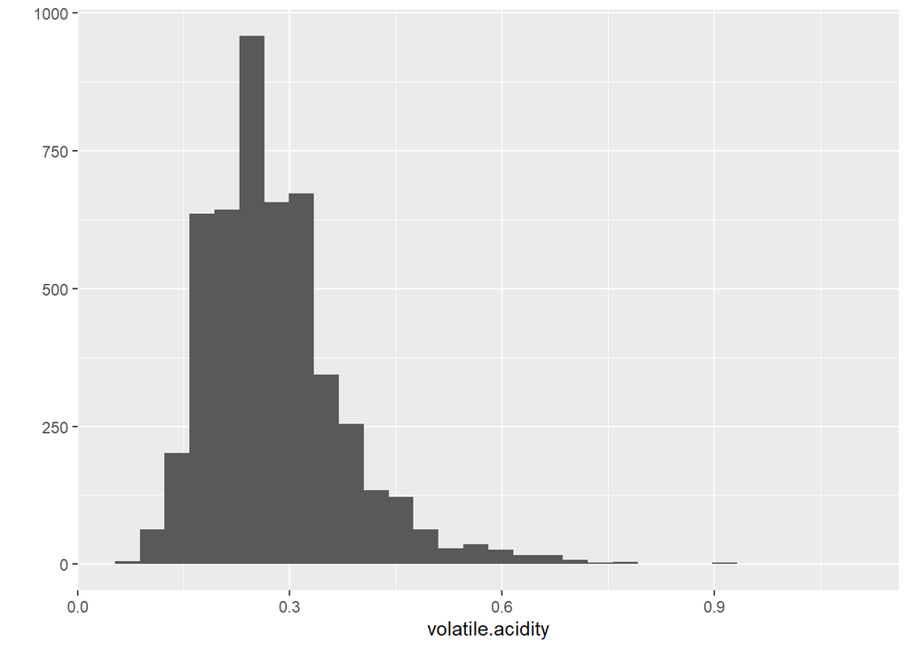

Volatile Acidity is centered around the 0.3 mark.

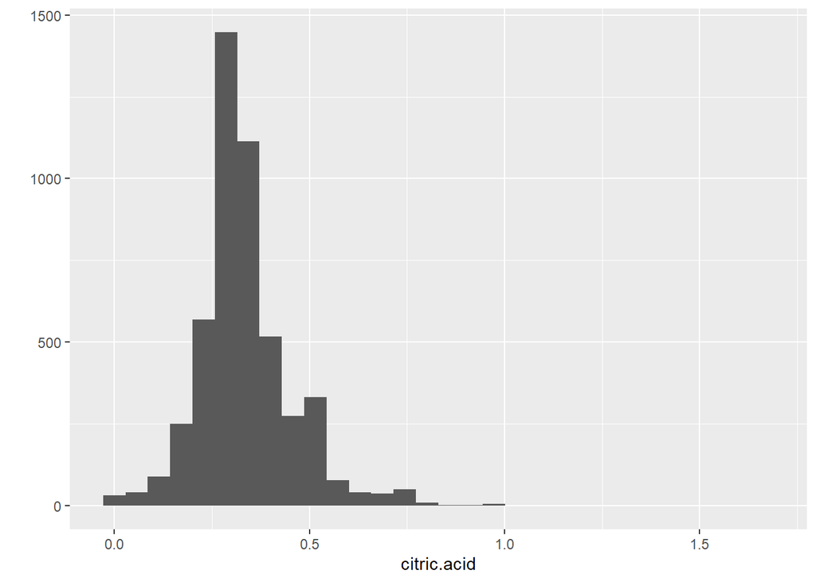

Citric Acid seems to fall on the lower end mostly under 0.5.

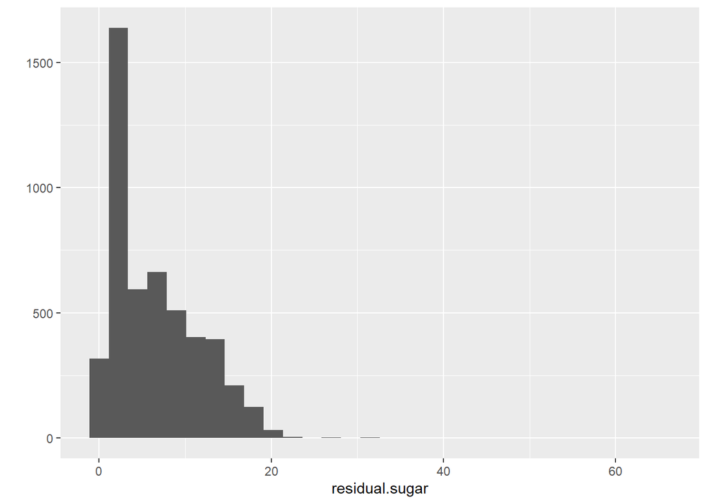

Residual Sugar also seems to be a low value around 5.

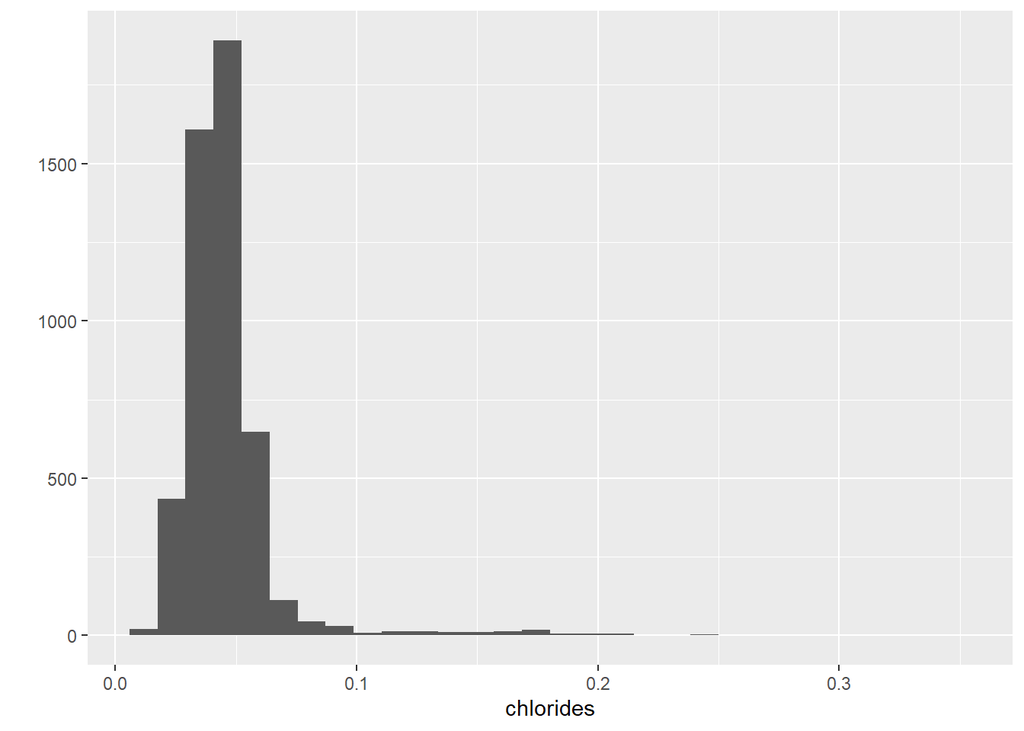

Chlorides have the lowest unit value of all, most wines fall lower than 0.1.

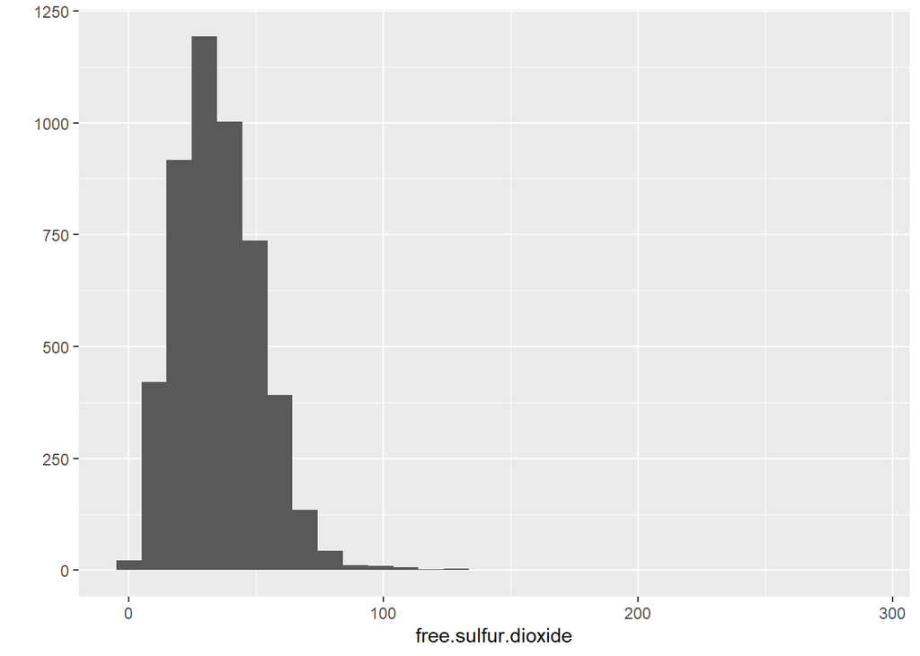

Free Sulfur Dioxide falls mostly below 50.

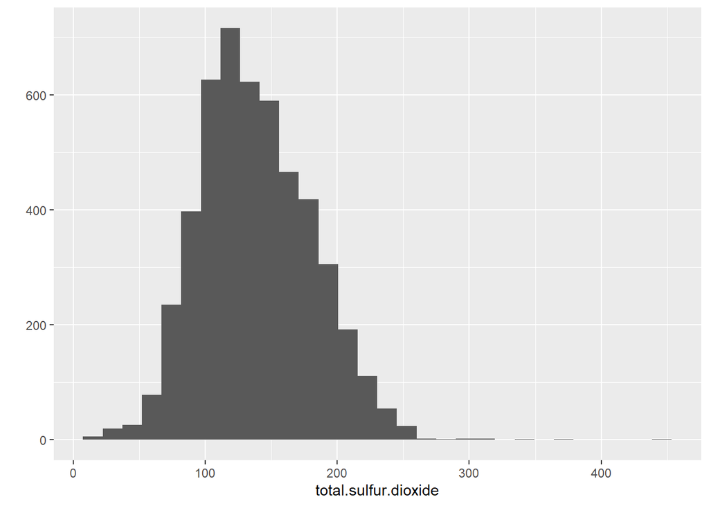

Total Sulfer Dioxide has a wider range than the free sulfer dioxide, between 100 and 200.

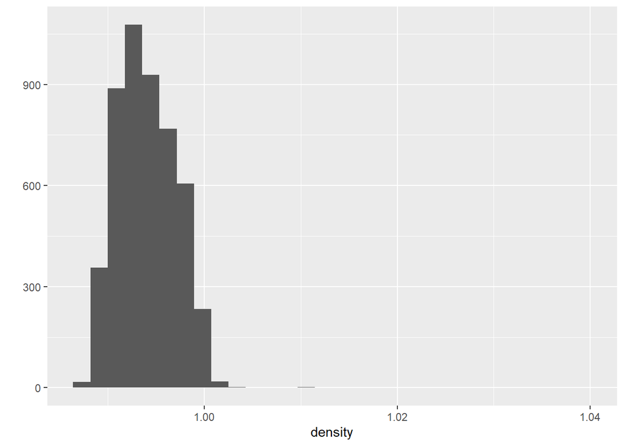

Density falls mostly below 1, but is a normal distribution it seems.

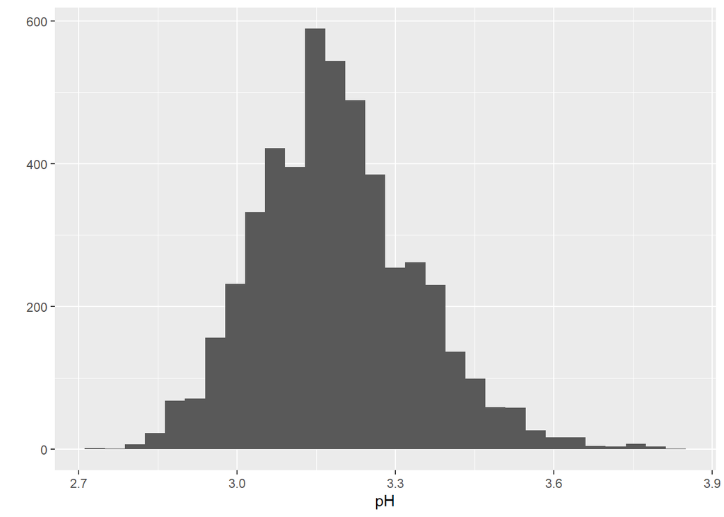

pH falls mostly between 3.0 and 3.6

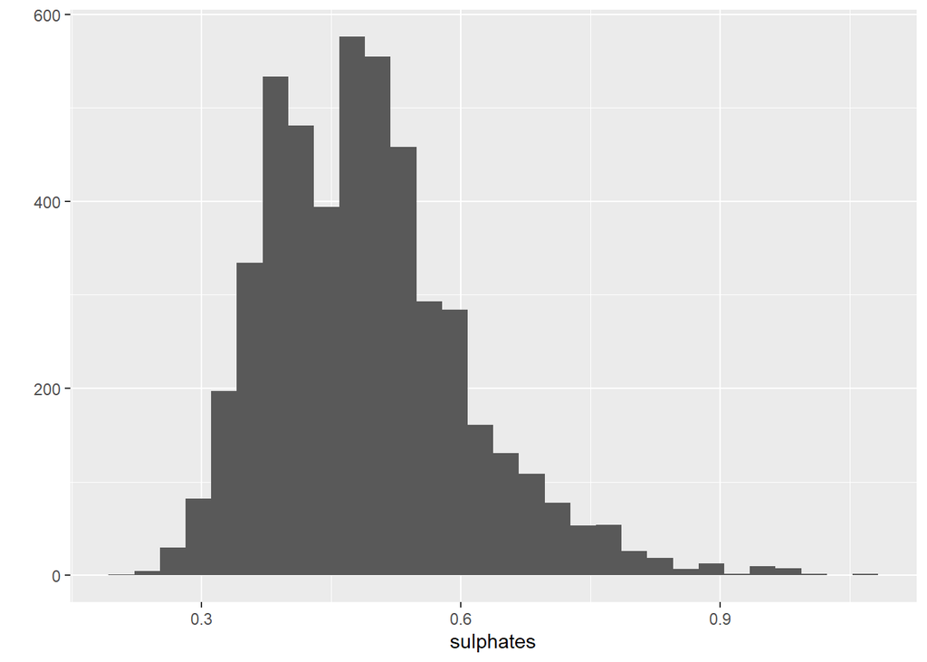

Sulphates have an unusual shape, but exist mostly between 0.3 and 0.6.

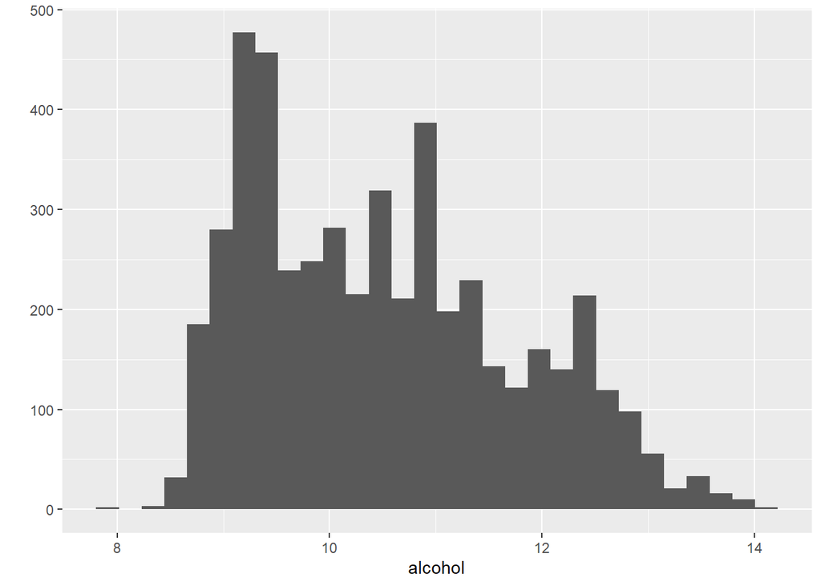

Based on these initial histograms run, I am starting to believe the biggest factors in determining quality are going to be citric.acid, pH, sulphates, and alcohol.

# Univariate Analysis

### What is the structure of your dataset?

There are 4,898 wines that have 12 features (fixed acidity, volatile acidity, citric acid, residual sugar, chlorides, free sulfer dioxide, total sulfer dioxide, density, pH, sulfates, alcohol, and qualtity).

Initial Observations: Most wines are of a quality of 6, with the lowest being 3 and the highest being 9. Almost all histogram curves are normalized except the alcohol curve.

### What is/are the main features of your dataset?

The main feature of the dataset is quality. I would like to determine what combination of features will determine the quality of a wine the most.

### What features do you think will help support your investigation?

I think the alcohol will play the largest role in the quality of the wine, but I think that citric acid, pH, and sulphates will play the largest supporting roles.

### Did you create any new variables from the existing variables?

I did not create any new variables, I did not see the need or the vision to combine variables in a meaningful way.

### Did you perform any operations to tidy, adjust, or change the form of the data?

No, but I may need to transform the data to dive deeper into some of the features.

# Bivariate Plots

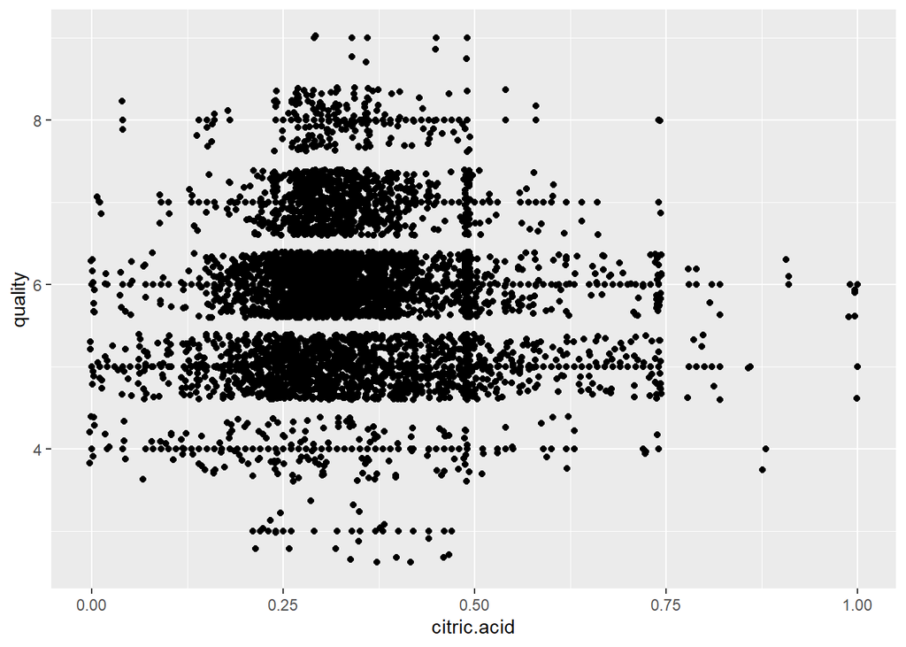

There seems to be a weak coorelation here if there is any at all. We can probably eliminate this as a top feature.

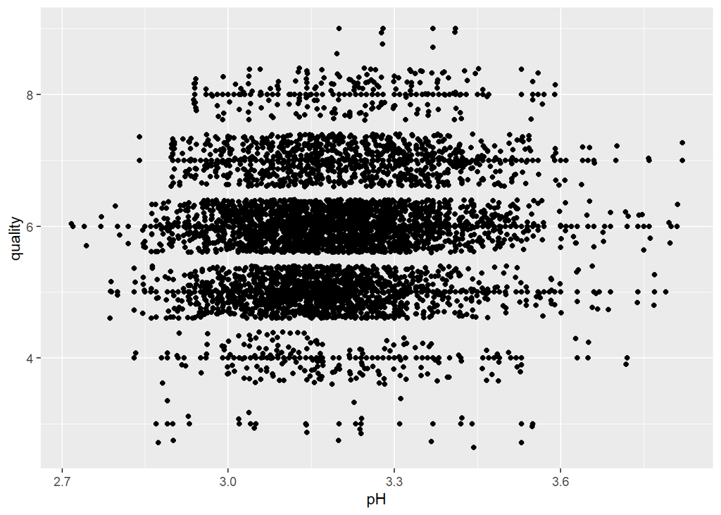

Once again, there does not appear to be a strong coorelation, meaning we will most likely remove pH as a top feature.

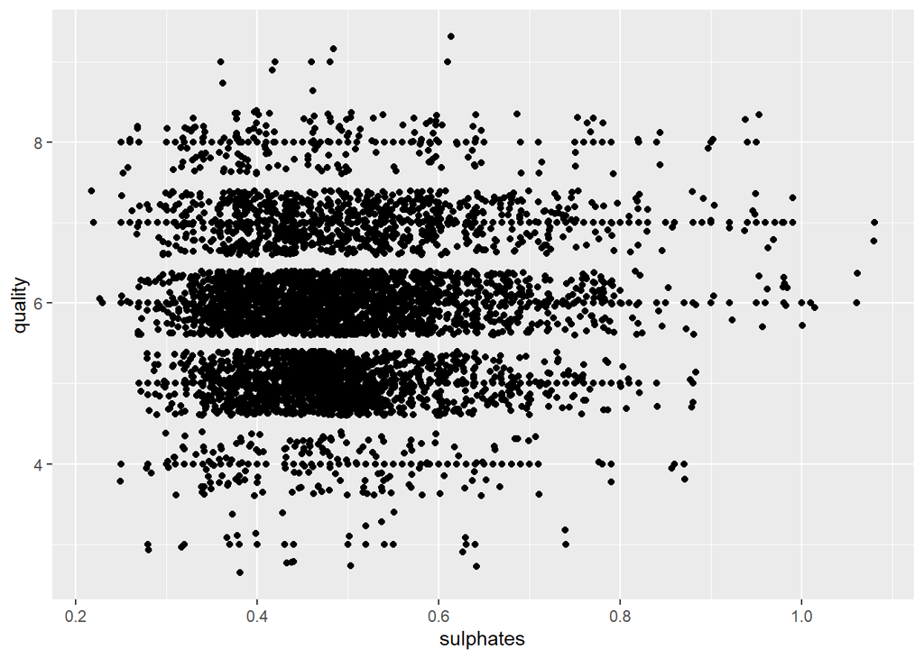

Now that we chart these features together, I can most likely eliminate sulphates as a top feature.

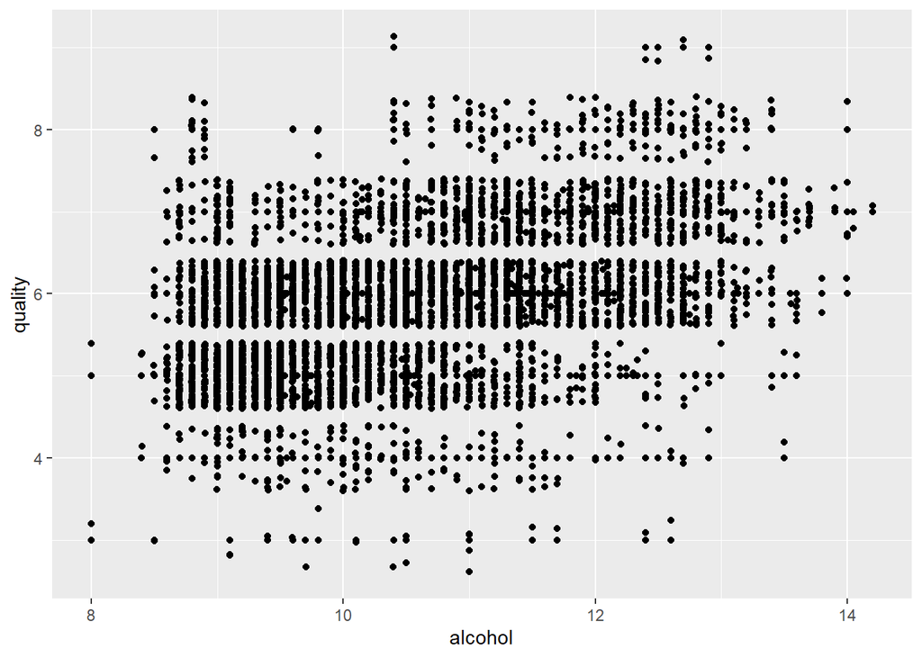

This shows a strong coorelation with the quality, meaning we should keep this as a top feature.

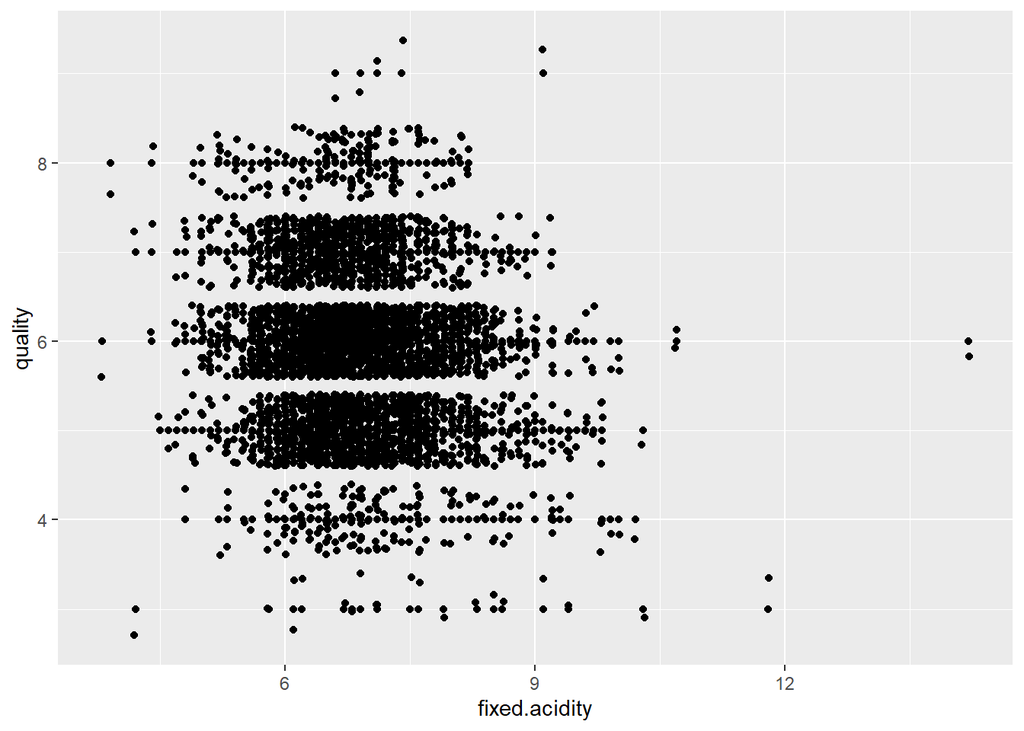

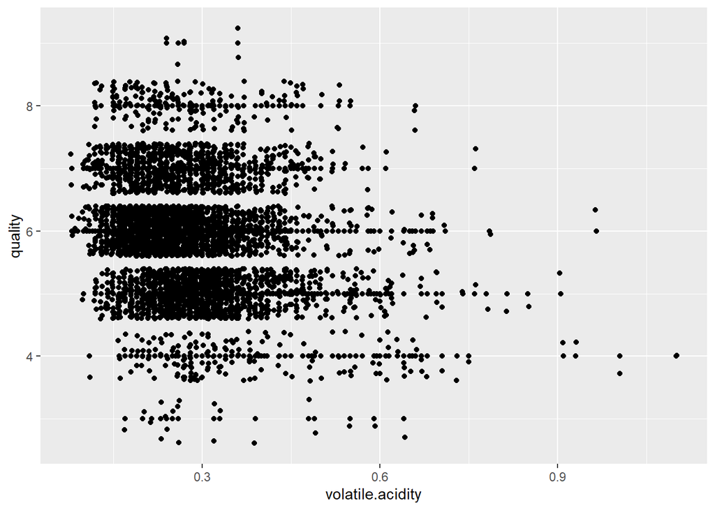

We can see a negative trend with the acidity features, and should keep this in mind going forward.

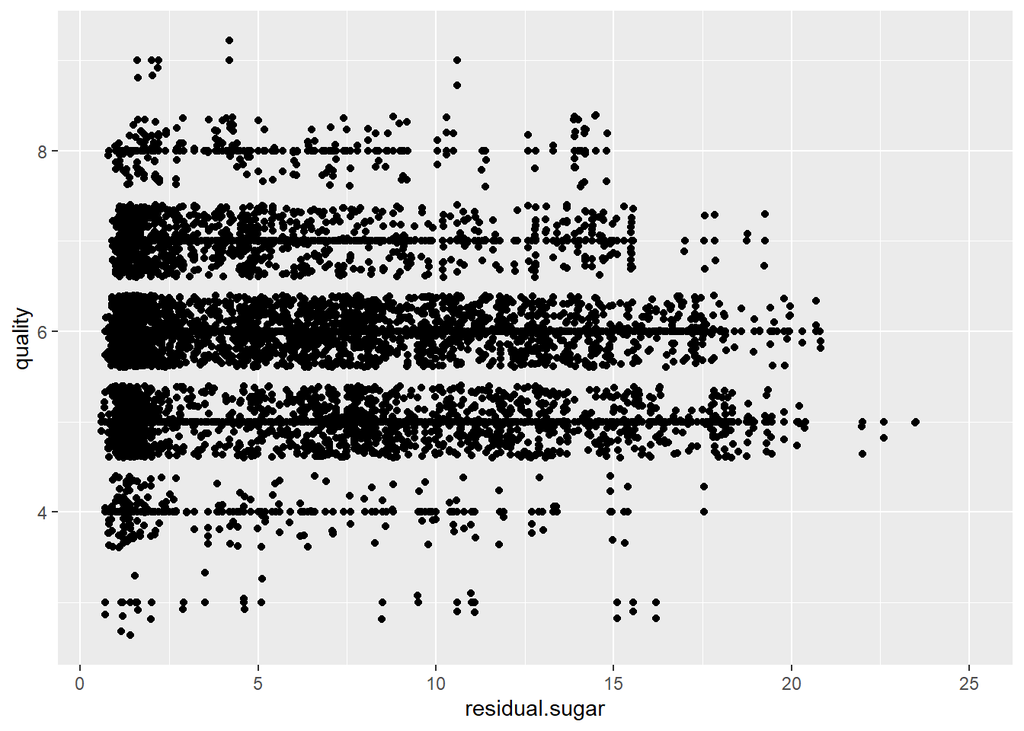

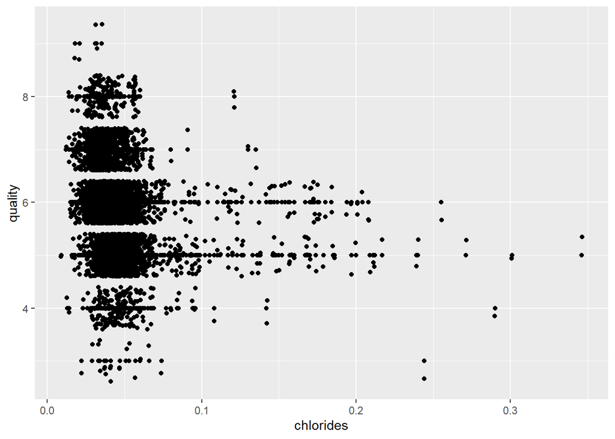

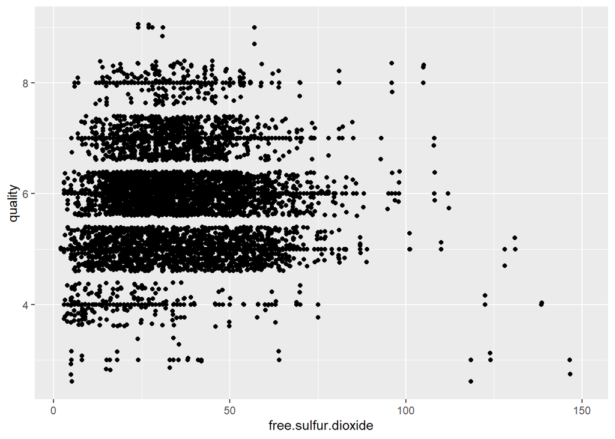

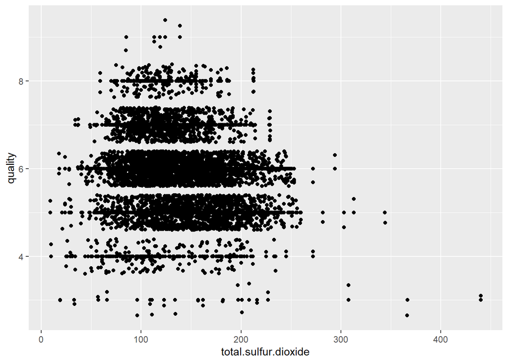

These four plots really don’t show any coorelation alone, and probably are not the top contributors.

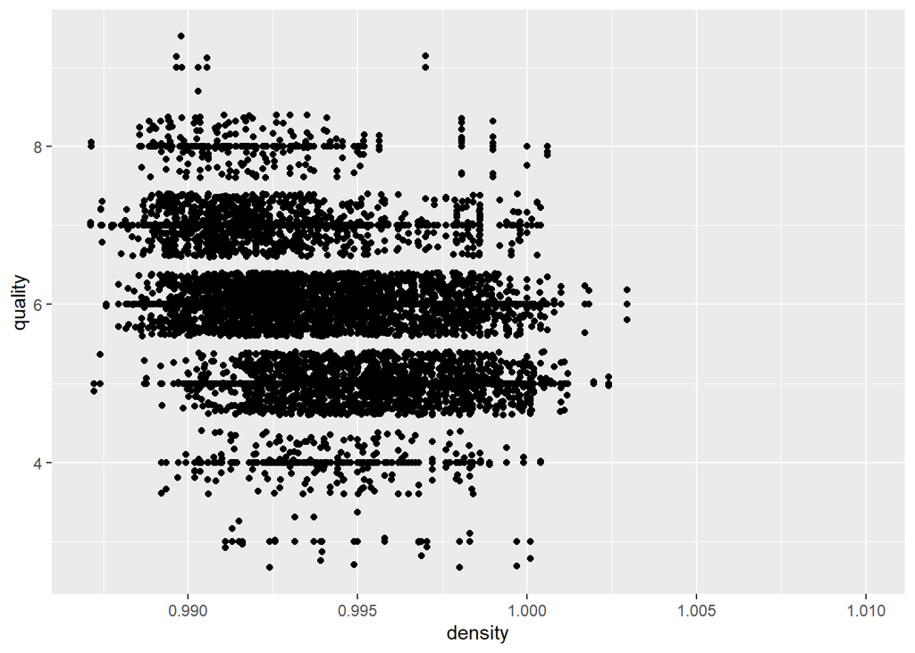

Density is interesting, because there is a definite trend towards lower density wines and higher quality. This feature should be investigated more.

# Bivariate Analysis

Talk about some of the relationships that you observed.

There are very few individual factors that go into determining the quality of the wine. I orginally thought that citric acid, pH, sulphates, and alochol might have the strongest indicators of quality. Happily, I can say that alcohol seems to have the strongest individual tie to quality. We can see from the scatterplot that as alcohol content increases, the genral quality of the wine also increases. Also, as the acidity levels of the wine increase, the quality of the wine decreases as well. Finally, density seems to have a relationship with quality.

Overall there seems to be a lack of individual factors that play into the overall quality. What this means going forward is that the combination of features used the play into a wine’s quality will need to be a combination of all the features that we have seen so far. I do believe that the highest quality of wine will contian a high alcohol content and low acidity levels, and the rest of the quality will be a combination of citric acid, sulphates and chlorides.

# Multivariate Plots

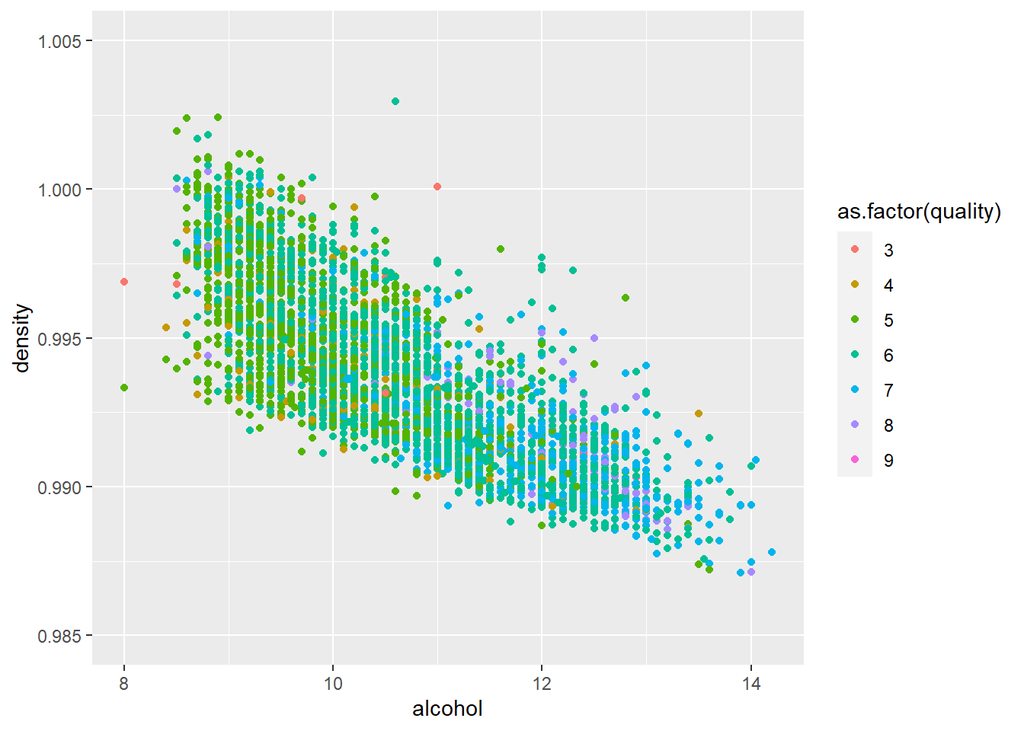

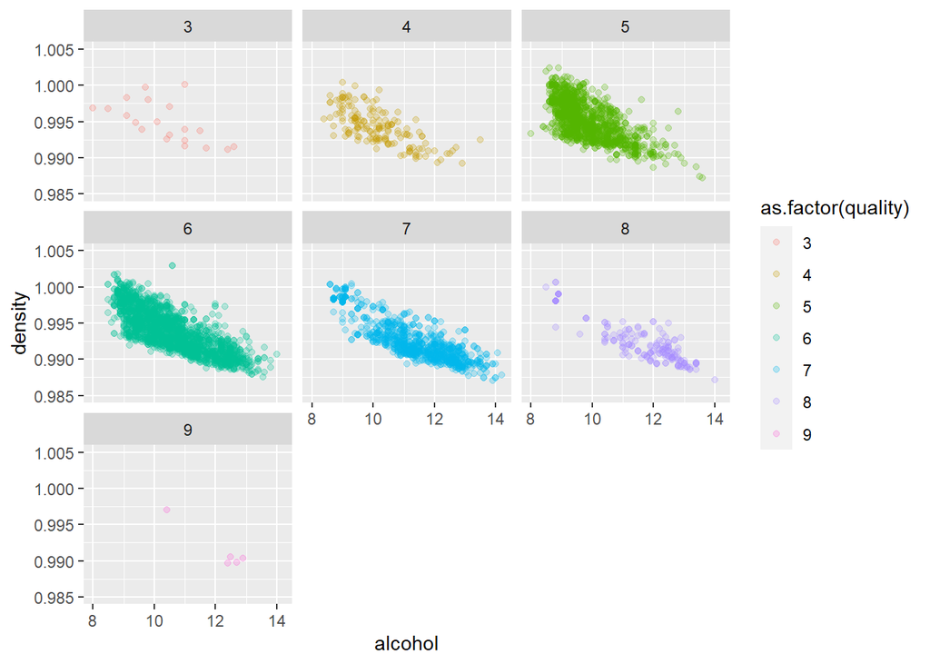

These two plots show a clear trend where as alcohol percentage increase, and density decreases the quality of the wine increases.

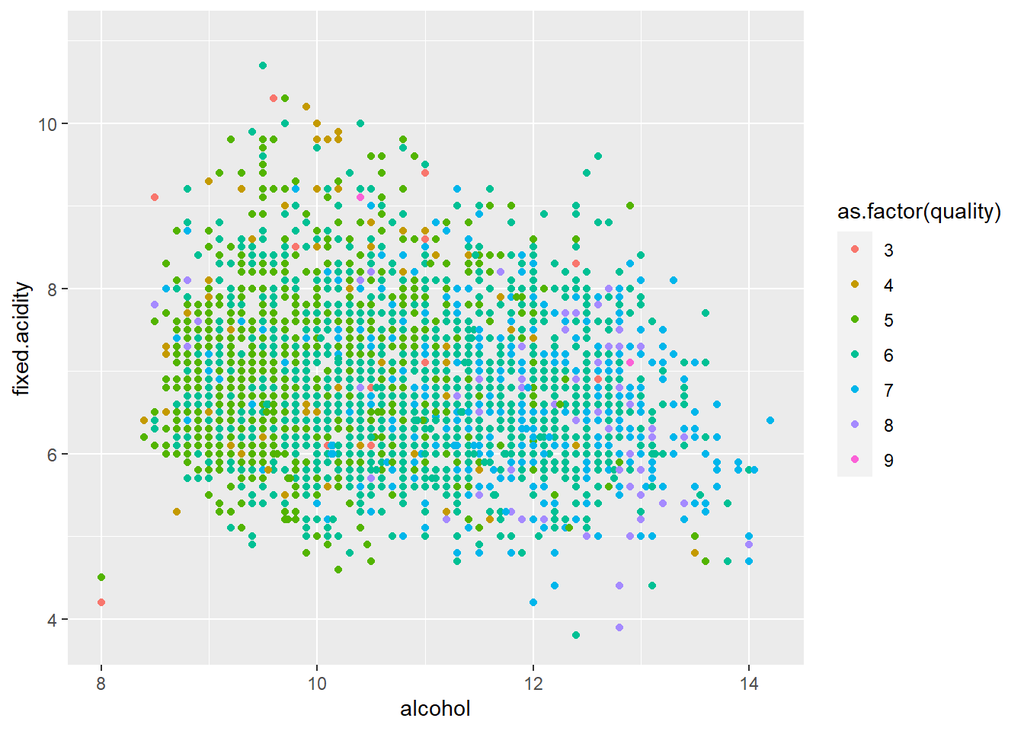

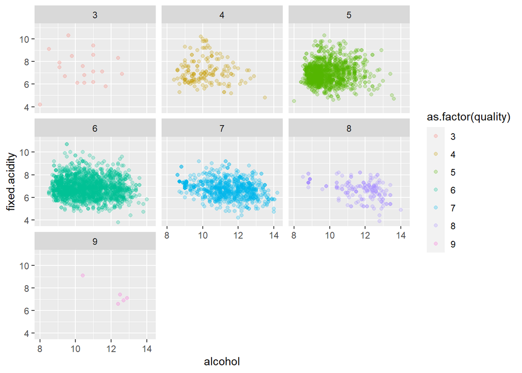

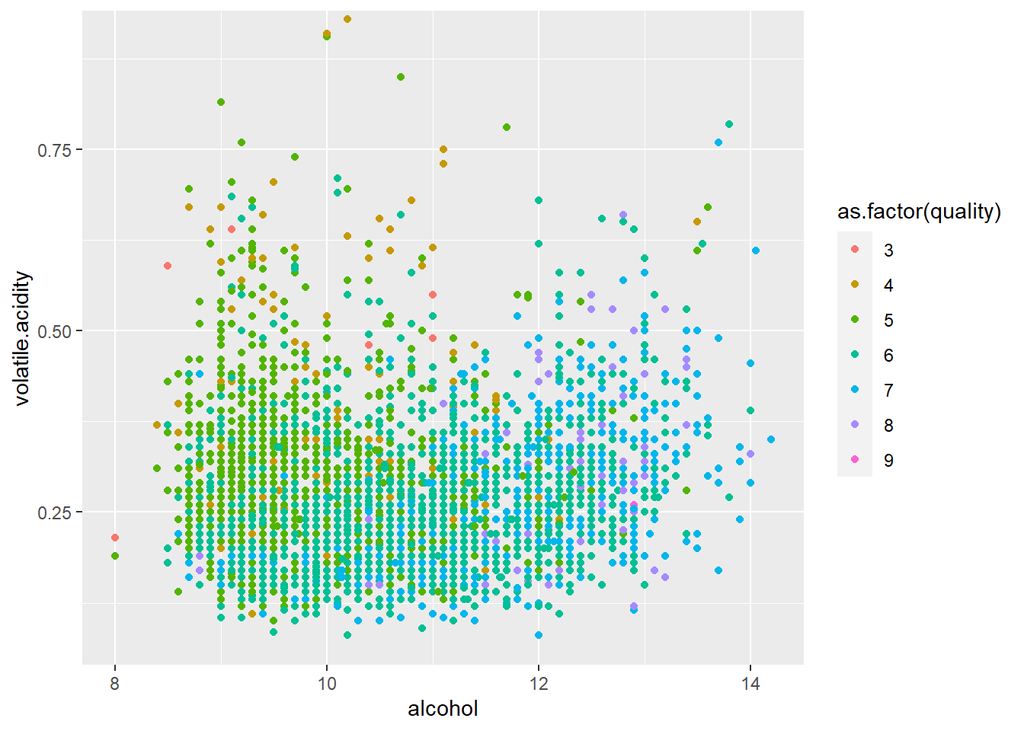

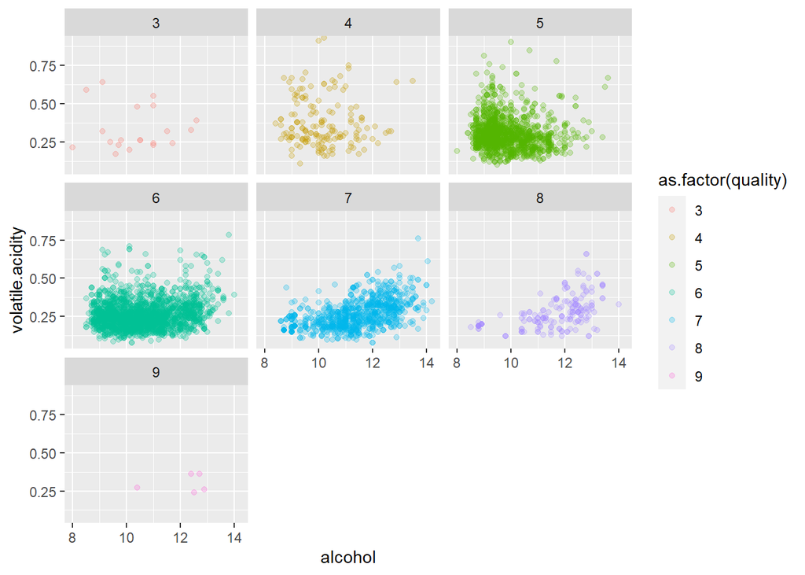

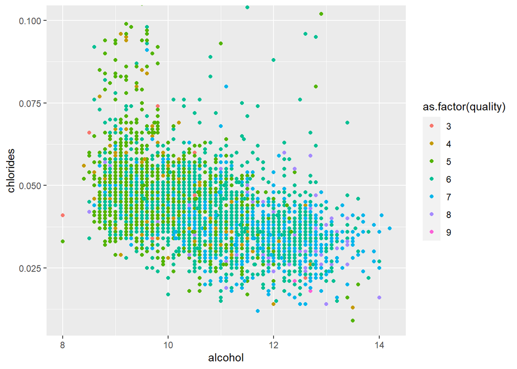

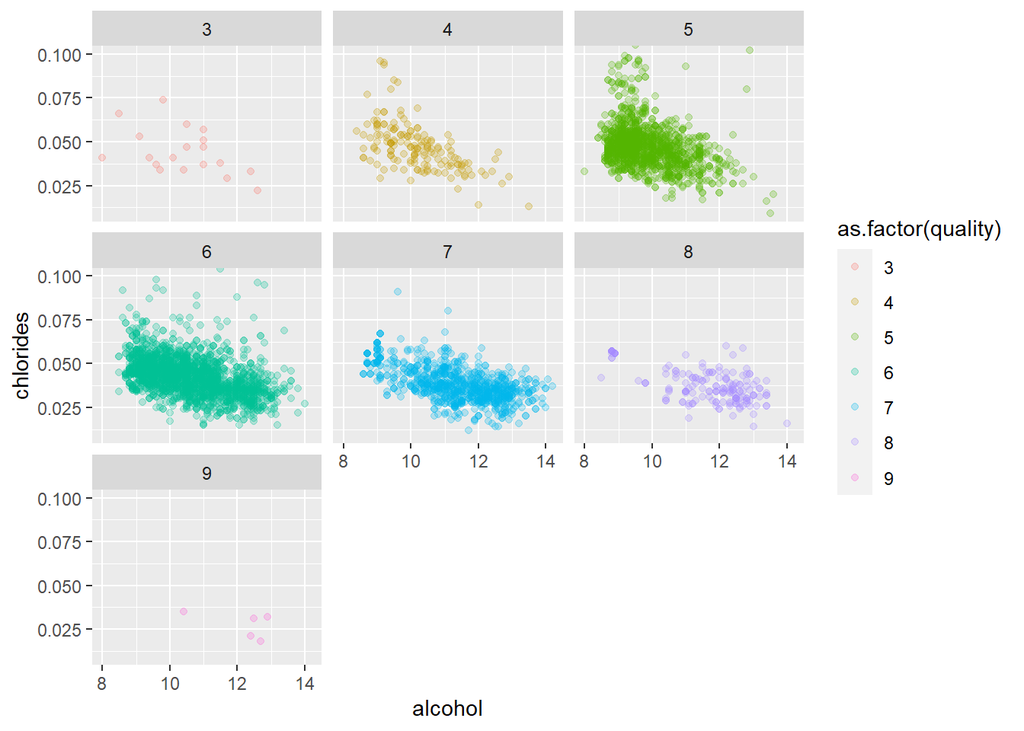

These other sets of plots really highlight that there is no stronger connection than alcohol and density when it comes to the quality of the wine.